# American Ninja Warrior - Kaplan-Meier Survival Analyis

Author

INSTRUCTOR KEY

# Getting Started: American Ninja Warrior Survival Analysis

```r
# Load packages
library(tidyverse)
library(survival)
library(survminer)

# Load Data
ninja <- read_csv("anw_2021_stage1.csv")
```

## Exercise 1: Data Structure

1. There are 69 observations in the data set (each representing a run of the course for a single competitor)
2. There are 5 variables: competitor name, sex, the obstacle name (this represents the last obstacle they reached in the run), the obstacle number, and the cause (why they did not move to further obstacles, could be either “Complete”, “Fall”, or “Time”)
3. The “time” variable here is the obstacle number.

## Point of Confusion: Second Run

Run the code below to remove the second run for Joe Moravsky from the data. If they students don’t do this they will get incorrect values later.

```r
ninja <- ninja |>
  filter(name != "Joe Moravsky (Safety Pass)")
```

# Kaplan-Meier Survival Analysis

## Exercise 2: Fake Data Table Completion

Calculating and filling in the NA values for obstacles 3 - 5 in the fake data summary table produces:

```r
fake_complete <- tibble(
  obstacle_number = c(1:5),
  fails = c(4,3,7,2,3),
  censored = c(0,4,0,0,2),
  at_risk = c(25,21,14,14-7,7-2),
  p_surv_cond = c(0.84,0.857,7/14,5/7,2/5),
  p_surv_km = c(0.84,0.72,0.5*0.72,0.714*0.36,0.4*0.257)
)
fake_complete
```

```
# A tibble: 5 × 6
  obstacle_number fails censored at_risk p_surv_cond p_surv_km
            <int> <dbl>    <dbl>   <dbl>       <dbl>     <dbl>
1               1     4        0      25       0.84      0.84
2               2     3        4      21       0.857     0.72
3               3     7        0      14       0.5       0.36
4               4     2        0       7       0.714     0.257
5               5     3        2       5       0.4       0.103
```

```r
# Makes a column called censor that is 1 if the competitor failed and 0 if they completed the course or ran out of time
ninja <- ninja |>
  mutate(censor = if_else(cause %in%  c("Complete", "Time"), 0, 1))
```

## Exercise 3: Manual Kaplan-Meier Calculation

#### Part 1: Number of Events

```r
ninja_summary <- ninja |>
  group_by(obstacle = obstacle_number) |>
  summarize(fails = sum(cause == "Fall"),
            censor = sum(cause %in% c("Complete", "Time")))
```

1. The most failures occurred at obstacle 4; 10 competitors failed that obstacle.
2. The obstacle with the most censored competitors (other than the last obstacle, which is completion) was obstacle 8; three ran out of time before being able to complete or fall on obstacle 9.

#### Part 2: At Risk Competitors

```r
ninja_summary <- ninja_summary |>
  mutate(attempts = 68 - lag(cumsum(fails), default = 0) - lag(cumsum(censor), default = 0))
```

1. All 68 were at risk at the first obstacle
2. Censored competitors do not attempt subsequent obstacles (at least fully) so need to be subtracted from the total for the next obstacle.

#### Part 3: Conditional Fail Probabilities

```r
ninja_summary <- ninja_summary |>
  mutate(fail_prob = fails / attempts)
```

2. 97.1 (100 minus 2.9) percent survived the first obstacle (66 out of 68)
3. Failed obstacle 5: 5/44 = 0.114, so 11.4%
4. Highest conditional fail probability was obstacle 4 at 18.5%
5. Obstacle 7 had a very slightly higher fail probability than Obstacle 2 (0.0789 vs 0.0757).

#### Part 4: Kaplan-Meier

```r
ninja_summary <- ninja_summary |>
  mutate(km = cumprod(1 - fail_prob))
```

1. Probability of surviving beyond first obstacle: 0.971
2. Probability of surviving beyond five obstacles: 0.574
3. Furthest obstacle with more than 0.5 probability of surviving is obstacle 7 (0.528). The estimated probability of surviving beyond obstacle 8 is below 0.5 at 0.451.

#### Part 5: Plotting the Kaplan-Meier Estimate

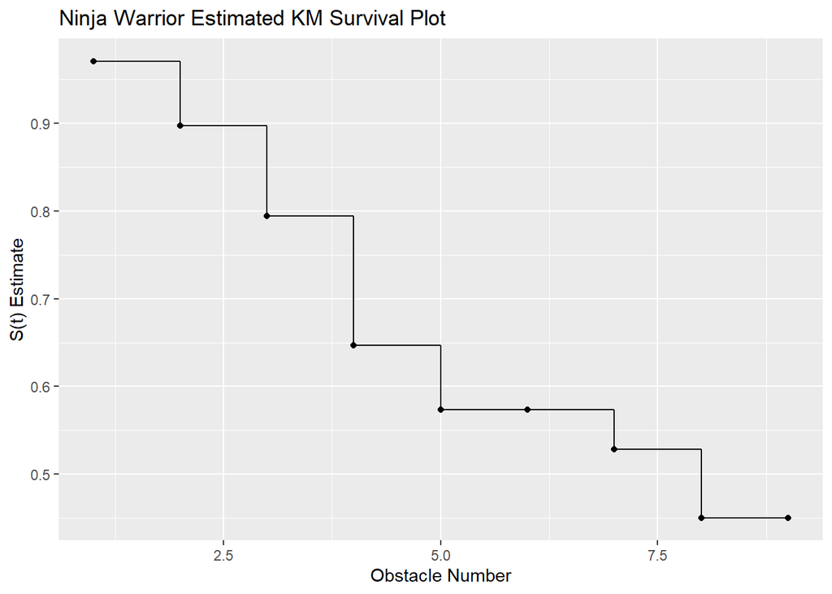

```r
ggplot(ninja_summary, aes(x = obstacle, y = km)) +
  geom_step() +
  geom_point() +
  labs(title = "Ninja Warrior Estimated KM Survival Plot",
       x = "Obstacle Number",
       y = "S(t) Estimate")
```

1. Plot produced using the code above.
2. We see the greatest decrease in survival probability at obstacle 4. There are obstacles with no failures (6,9) where the curve stays at the same value.
3. The curve never reaches 0, lowest value around 0.45 (we know the exact value is 0.451) since there are competitors censored on the last obstacle (i.e. they complete the course, and have not failed an obstacle yet).

# R for Kaplan-Meier

```r
ninja_km <- survfit(Surv(obstacle_number, censor) ~ 1, data = ninja)
summary(ninja_km)
```

```
Call: survfit(formula = Surv(obstacle_number, censor) ~ 1, data = ninja)

 time n.risk n.event survival std.err lower 95% CI upper 95% CI
    1     68       2    0.971  0.0205        0.931        1.000
    2     66       5    0.897  0.0369        0.828        0.972
    3     61       7    0.794  0.0490        0.704        0.896
    4     54      10    0.647  0.0580        0.543        0.771
    5     44       5    0.574  0.0600        0.467        0.704
    7     38       3    0.528  0.0607        0.422        0.662
    8     34       5    0.451  0.0609        0.346        0.587
```

## Exercise 4: Kaplan-Meier Estimates and Interpretation

1. The survival probabilities from the R command match what we computed previously.
2. The first CI which includes 0.5 is at obstacle 5: (0.467, 0.704)
3. The standard error of the KM survival probability estimate increases as time (obstacle number) increases. This makes sense; there are fewer samples (number at risk) at each subsequent obstacles leading to less certainty about estimates.

## Exercise 5: Interprating Quantiles

```r
quantile(ninja_km)
```

```
$quantile
25 50 75
 4  8 NA

$lower
25 50 75
 3  5 NA

$upper
25 50 75
 5 NA NA
```

## Plotting Kaplan-Meier with R

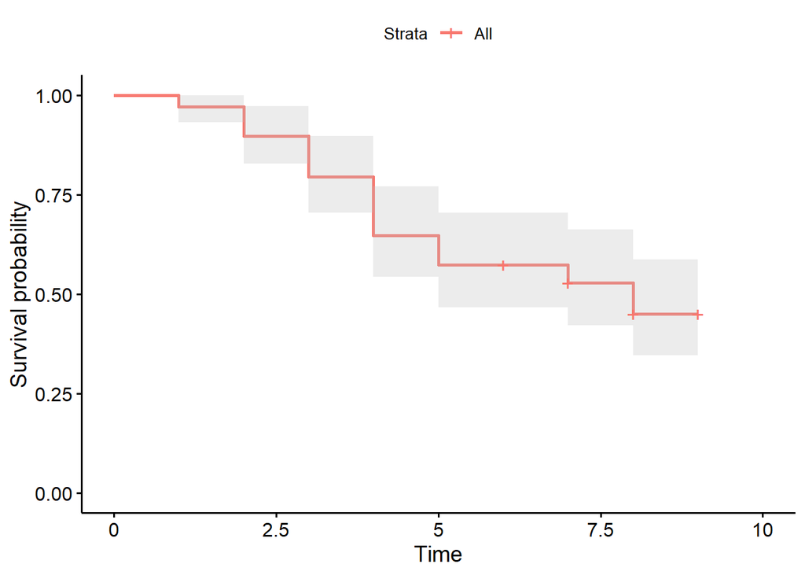

```r
ggsurvplot(ninja_km,
           conf.int = TRUE)
```

# Kaplan-Meier Estimator by Groups

```r
ninja_km_gender <- survfit(Surv(obstacle_number,
                                censor)~ sex, data = ninja)
```

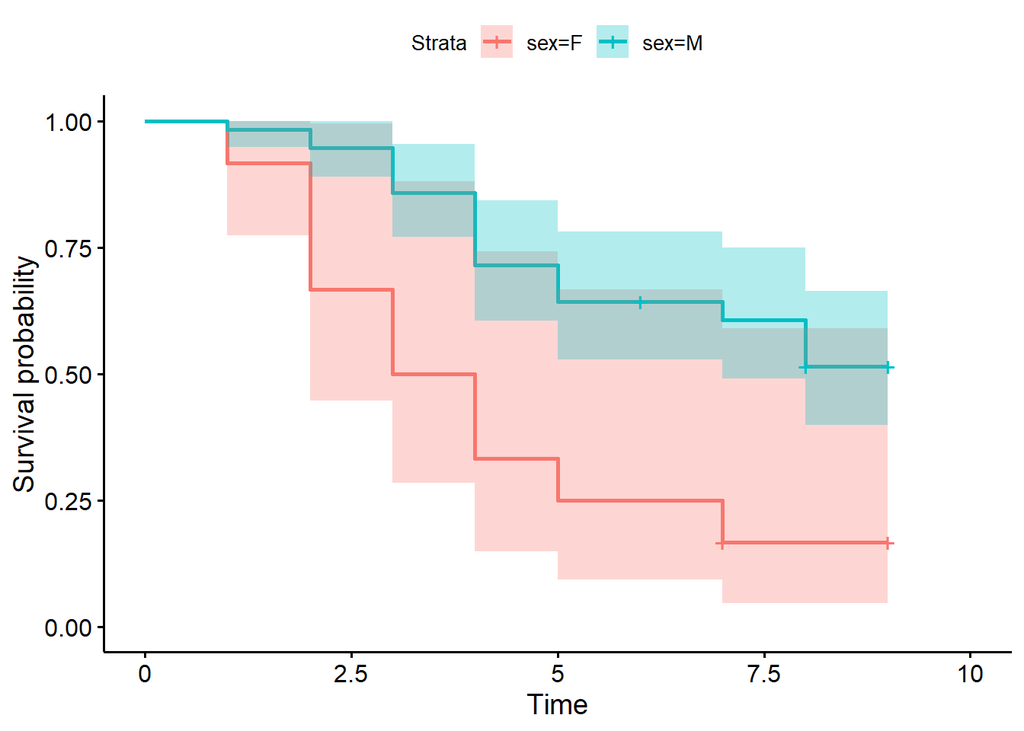

```r
ggsurvplot(ninja_km_gender,
           conf.int = TRUE)
```

## Exercise 6: Kaplan-Meier Estimates by Group

1. Males have higher survival probabilities for all but possibly the first obstacle.
2. The CI for females is wider (shaded area greater)
3. There are fewer female competitors so we have less precision for their estimated probabilities.

## Exercise 7: Comparing Survival Vs. Expected Survival

```r
ninja_km_diff <- survdiff(Surv(obstacle_number,
                               censor) ~ sex, data = ninja)
ninja_km_diff
```

```
Call:
survdiff(formula = Surv(obstacle_number, censor) ~ sex, data = ninja)

       N Observed Expected (O-E)^2/E (O-E)^2/V
sex=F 12       10     4.05      8.72      11.1
sex=M 56       27    32.95      1.07      11.1

 Chisq= 11.1  on 1 degrees of freedom, p= 9e-04
```

## Exercise 8: Log Rank Tests

```r
surv_pvalue(ninja_km_gender) #log rank
```

```
  variable         pval   method    pval.txt
1      sex 0.0008586398 Log-rank p = 0.00086
```

```r
surv_pvalue(ninja_km_gender, method = "n") #Gehan Breslow (generalized Wilcoxon)
```

```
  variable  pval        method  pval.txt
1      sex 8e-04 Gehan-Breslow p = 8e-04
```

```r
surv_pvalue(ninja_km_gender, method = "TW") #Tarone-Ware
```

```
  variable  pval      method  pval.txt
1      sex 9e-04 Tarone-Ware p = 9e-04
```

```r
surv_pvalue(ninja_km_gender, method = "PP") #Peto-Prentice
```

```
  variable  pval    method  pval.txt
1      sex 7e-04 Peto-Peto p = 7e-04
```

```r
surv_pvalue(ninja_km_gender, method = "FH") #Fleming-Harrington
```

```
  variable   pval                        method pval.txt
1      sex 0.0296 Fleming-Harrington (p=1, q=1) p = 0.03
```

1. All tests have p-values less than 0.05 so the conclusions would remain unchanged using this cutoff value.
2. Smallest p-value: Peto-Prentice (7e-04)
3. Largest p-value: Fleming-Harrington (0.03)
4. More significant early (Peto-Prentice and Wilcoxon weight these points more and had the smallest p-values). Note that the graph starts to separate more early and then that separation remains somewhat constant. Also, the sample sizes get much smaller at the later points so when those are weighted more we have less ability to detect differences (wider CI)

# More Practice

## Challenge 1: Cleaning Data

1. Code to load data and removed 2nd run (RJ Roman):

   ```r
   # Load Data
   ninja23 <- read_csv("anw_2023_stage1.csv")
   ninja23 <- ninja23 |>
     filter(name != "RJ Roman 2nd run")
   ```

2. A second run allows the ninja to practice the obstacles and thus this is not an independent observation as with the others
3. Code to add a 0-1 censor variable:

```r
ninja23 <- ninja23 |>
  mutate(censor = if_else(cause %in%  c("Complete", "Time"), 0, 1))
```

## Challenge 2: Fitting KM

1. Code to produce KM estimates:

   ```r
   ninja23_km <- survfit(Surv(obstacle_number, censor) ~ 1, data = ninja23)
   summary(ninja23_km)
   ```

   ```
   Call: survfit(formula = Surv(obstacle_number, censor) ~ 1, data = ninja23)

    time n.risk n.event survival std.err lower 95% CI upper 95% CI
       2     73       4    0.945  0.0266        0.894        0.999
       3     69       6    0.863  0.0402        0.788        0.946
       4     63      13    0.685  0.0544        0.586        0.800
       5     50      12    0.521  0.0585        0.418        0.649
       7     35       3    0.476  0.0589        0.373        0.606
       8     27      11    0.282  0.0569        0.190        0.419
   ```

2. 50 were still at risk at obstacle 5
3. Estimated probability of surviving past obstacle 7 is 0.476

   ```r
   quantile(ninja23_km)
   ```

   ```
   $quantile
   25 50 75
    4  7 NA

   $lower
   25 50 75
    4  5  8

   $upper
   25 50 75
    5  8 NA
   ```

4. Estimated median obstacles survived is 7 (code above)

## Challenge 3: Comparing Groups

1. Code to obtain the survival estimates by group and get differences:

   ```r
   ninja23_km_gender <- survfit(Surv(obstacle_number,
                                   censor)~ sex, data = ninja23)

   ninja23_km_diff <- survdiff(Surv(obstacle_number,
                                  censor) ~ sex, data = ninja23)
   ```

2. The test statistic value of the log-rank test is 18.4 (code below)

   ```r
   ninja23_km_diff
   ```

   ```
   Call:
   survdiff(formula = Surv(obstacle_number, censor) ~ sex, data = ninja23)

          N Observed Expected (O-E)^2/E (O-E)^2/V
   sex=F 16       14     5.51     13.08      18.4
   sex=M 57       35    43.49      1.66      18.4

    Chisq= 18.4  on 1 degrees of freedom, p= 2e-05
   ```

3. Based on the log-rank test (p < 0.0001) we have evidence of a difference in survival experience based on sex of competitors.
4. Plot by groups code:

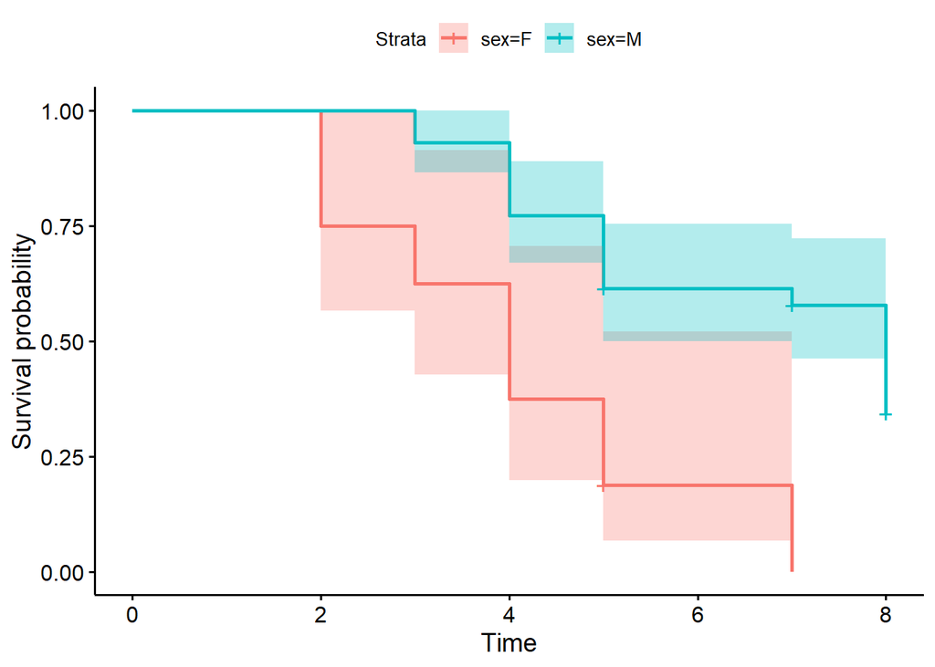

```r
ggsurvplot(ninja23_km_gender,
           conf.int = TRUE)
```

e. In the plot it appears that the probability of males surviving past obstacle 8 is higher (or about the same) as the probability for females surviving beyond obstacle 4. Both are around 0.35. We can look at the summary to get the actual estimates (code below). 0.375 for females beyond obstacle 4 is barely higher than 0.342 (but about the same) for males beyond obstacle 8.

```r
summary(ninja23_km_gender)
```

```
Call: survfit(formula = Surv(obstacle_number, censor) ~ sex, data = ninja23)

                sex=F
 time n.risk n.event survival std.err lower 95% CI upper 95% CI
    2     16       4    0.750  0.1083       0.5652        0.995
    3     12       2    0.625  0.1210       0.4276        0.914
    4     10       4    0.375  0.1210       0.1992        0.706
    5      6       3    0.188  0.0976       0.0676        0.520
    7      1       1    0.000     NaN           NA           NA

                sex=M
 time n.risk n.event survival std.err lower 95% CI upper 95% CI
    3     57       4    0.930  0.0338        0.866        0.999
    4     53       9    0.772  0.0556        0.670        0.889
    5     44       9    0.614  0.0645        0.500        0.754
    7     34       2    0.578  0.0656        0.463        0.722
    8     27      11    0.342  0.0670        0.233        0.503
```

f. From the graph it appears that at obstacle 4 the confidence intervals for the two groups overlap (we see a gray area which is how this overlap is depicted, rather than white). The summary above confirms that the upper CI value for females is 0.706 and the lower value for males 0.67 so they overlap. We lack evidence that the true probabilities differ at obstacle 4.